# Communication Data Findings Project

The **Communication Data Findings Project** as a part of the **Udacity Adanced Data Analyst Nano-Degree Program** is focusing on **exploratory data visualization** and **explanatory data visualization**.

By `Sherif Sakr`

`Cairo, Egypt`

**Dataset**

**Bay Wheels Bike Sharing System, Ford GoBike**

`Bay Wheels` is a regional public `bicycle sharing system` in `San Francisco Bay Area`, `California`. It is operated by Motivate in a partnership with the Metropolitan Transportation Commission and the Bay Area Air Quality Management District. Bay Wheels is the first regional and large-scale bicycle sharing system deployed in California and on the West Coast of the United States. It was established as Bay Area Bike Share in August 2013. As of January 2018, the Bay Wheels system had over 2,600 bicycles in 262 stations across San Francisco, East Bay and San Jose.

However, in June 2017 the system was officially re-launched as `Ford GoBike` in a partnership with Ford Motor Company. After Motivate's acquisition by Lyft, the system was renamed to Bay Wheels in June 2019.

**Exploratory vs. Explanatory analyses**

**Exploratory analysis** is what you do to get familiar with the data. You may start out with a hypothesis or question, or you may just really be delving into the data to determine what might be interesting about it. Exploratory analysis is the process of turning over 100 rocks to find perhaps 1 or 2 precious gemstones.

Exploratory analysis is done for searching for insights, looking for relationship in the data, connect to questions about data, and visualizations do not need to be perfect.

Exploratory data visualization generally occurs during and after the data wrangling process, and is the main method that you will use to understand the patterns and relationships present in your data. This understanding will help you approach any statistical analyses and will help you build conclusions and findings. This process might also illuminate additional data cleaning tasks to be performed.

**Explanatory analysis** is what happens when you have something specific you want to show an audience - probably about those 1 or 2 precious gemstones. In my blogging and writing, I tend to focus mostly on this latter piece, explanatory analysis, when you've already gone through the exploratory analysis and from this have determined something specific you want to communicate to a given audience: in other words, when you want to tell a story with data.

Explanatory analysis is done when providing the results for others, and to highlight insight, surrounded by a story, and do not include unneeded information.

Explanatory data visualization techniques are used after generating your findings, and are used to help communicate your results to others. Understanding design considerations will make sure that your message is clear and effective. In addition to being a good producer of visualizations, going through this project will also help you be a good consumer of visualizations that are presented to you by others.

**Quantitative Data vs. Qualitative Data**

- Quantitative data is the data that is measured in numbers. It deals with numbers that make sense to perform arithmetic calculation with. It consists of discrete variables and continuous variables.
- Qualitative data or categorical data referes to the values that place 'things' into different groups or categories.It consists of ordinal variables and nominal variables.

**Python Data Visualization Libraries**

- Matplotlib

A versatile library for visualization, but it can take some code effect to put together common visualizations.

- Seaborn

Built on top of Matplotlib, adds a number of functions to make common statistical visualizations easier to generate.

- Pandas

While this library includes some convenient methods for visualizating data that hook into Matplotlib, It mainly be used for its main purpose as a general tool for working with data.

- All Python Data Visualization Libraries together will allow you to visualize data in a balance of productivity and flexibility, for both exploratory as well as explanatory analyses.

```python
# Load Modules
import numpy as np
import pandas as pd
import matplotlib.pyplot as plt
import seaborn as sb
import random
import os
import glob
%matplotlib inline
from matplotlib import rcParams
```

### wrangling data (data gathering, data assessing, and data cleaning)

```python
# Load 2021_01_28_fordgobike_tripdata.csv data and store it in the DataFrame.
# Use pandas.read_csv() function to read a comma-separated values(csv) file into DataFrame.
df1 = pd.read_csv('2021_01_28_fordgobike_tripdata.csv')

# Use pandas.DataFrame.shape function to return a tuple representing the dimensionality of the DataFrame
print(df1.shape)

# Use a pandas.DataFrame.head(n=5) function to return the first numbers of rows for the object based on position.
df1.head()
```

```
(183412, 16)
```

|  | duration_sec | start_time | end_time | start_station_id | start_station_name | start_station_latitude | start_station_longitude | end_station_id | end_station_name | end_station_latitude | end_station_longitude | bike_id | user_type | member_birth_year | member_gender | bike_share_for_all_trip |
| --- | --- | --- | --- | --- | --- | --- | --- | --- | --- | --- | --- | --- | --- | --- | --- | --- |
| 0 | 52185 | 2019-02-28 17:32:10.1450 | 2019-03-01 08:01:55.9750 | 21.0 | Montgomery St BART Station (Market St at 2nd St) | 37.789625 | -122.400811 | 13.0 | Commercial St at Montgomery St | 37.794231 | -122.402923 | 4902 | Customer | 1984.0 | Male | No |
| 1 | 42521 | 2019-02-28 18:53:21.7890 | 2019-03-01 06:42:03.0560 | 23.0 | The Embarcadero at Steuart St | 37.791464 | -122.391034 | 81.0 | Berry St at 4th St | 37.775880 | -122.393170 | 2535 | Customer | NaN | NaN | No |
| 2 | 61854 | 2019-02-28 12:13:13.2180 | 2019-03-01 05:24:08.1460 | 86.0 | Market St at Dolores St | 37.769305 | -122.426826 | 3.0 | Powell St BART Station (Market St at 4th St) | 37.786375 | -122.404904 | 5905 | Customer | 1972.0 | Male | No |
| 3 | 36490 | 2019-02-28 17:54:26.0100 | 2019-03-01 04:02:36.8420 | 375.0 | Grove St at Masonic Ave | 37.774836 | -122.446546 | 70.0 | Central Ave at Fell St | 37.773311 | -122.444293 | 6638 | Subscriber | 1989.0 | Other | No |
| 4 | 1585 | 2019-02-28 23:54:18.5490 | 2019-03-01 00:20:44.0740 | 7.0 | Frank H Ogawa Plaza | 37.804562 | -122.271738 | 222.0 | 10th Ave at E 15th St | 37.792714 | -122.248780 | 4898 | Subscriber | 1974.0 | Male | Yes |

```python
# Use pandas.DataFrame.dtypes function to return the data types in the DataFrame
print(df1.dtypes)
```

```
duration_sec                 int64
start_time                  object
end_time                    object
start_station_id           float64
start_station_name          object
start_station_latitude     float64
start_station_longitude    float64
end_station_id             float64
end_station_name            object
end_station_latitude       float64
end_station_longitude      float64
bike_id                      int64
user_type                   object
member_birth_year          float64
member_gender               object
bike_share_for_all_trip     object
dtype: object
```

```python
# Use pandas DataFrame.iloc[] for integer-location based indexing for selection by position
df1.iloc[0]
```

```
duration_sec                                                          52185
start_time                                         2019-02-28 17:32:10.1450
end_time                                           2019-03-01 08:01:55.9750
start_station_id                                                         21
start_station_name         Montgomery St BART Station (Market St at 2nd St)
start_station_latitude                                              37.7896
start_station_longitude                                            -122.401
end_station_id                                                           13
end_station_name                             Commercial St at Montgomery St
end_station_latitude                                                37.7942
end_station_longitude                                              -122.403
bike_id                                                                4902
user_type                                                          Customer
member_birth_year                                                      1984
member_gender                                                          Male
bike_share_for_all_trip                                                  No
Name: 0, dtype: object
```

```python
# Use pandas.DataFrame.ndim to return an integer representing the number of axes/ array dimensions.
df1.ndim
```

```
2
```

```python
# Use pandas.DataFrame.size to return an integer representing the number of elements in the object.
# It returns the number of rows if Series. Otherwise, it returns the number of rows times number of columns if DataFrame.
df1.size
```

```
2934592
```

```python
# Use a Python built-in function list() to return a list in Python (the column names in pandas.DataFrame)
list(df1)
```

```
['duration_sec',
 'start_time',
 'end_time',
 'start_station_id',
 'start_station_name',
 'start_station_latitude',
 'start_station_longitude',
 'end_station_id',
 'end_station_name',
 'end_station_latitude',
 'end_station_longitude',
 'bike_id',
 'user_type',
 'member_birth_year',
 'member_gender',
 'bike_share_for_all_trip']
```

```python
# Use pandas.DataFrame.isnull() method to detect the Null values or missing values.
df1.isnull().any()
```

```
duration_sec               False
start_time                 False
end_time                   False
start_station_id            True
start_station_name          True
start_station_latitude     False
start_station_longitude    False
end_station_id              True
end_station_name            True
end_station_latitude       False
end_station_longitude      False
bike_id                    False
user_type                  False
member_birth_year           True
member_gender               True
bike_share_for_all_trip    False
dtype: bool
```

```python
# Use pandas.DataFrame.value_counts() function to return a Series containing counts of unique rows in the DataFrame
df1.user_type.value_counts()
```

```
Subscriber    163544
Customer       19868
Name: user_type, dtype: int64
```

```python
# Use pandas.value_counts(normalize=True) function to return a Series containing the relative frequencies of the unique values.
df1.user_type.value_counts(normalize=True)
```

```
Subscriber    0.891676
Customer      0.108324
Name: user_type, dtype: float64
```

```python
# Use pandas.DataFrame.value_counts() function to return a Series containing counts of unique rows in the DataFrame
df1.member_gender.value_counts()
```

```
Male      130651
Female     40844
Other       3652
Name: member_gender, dtype: int64
```

```python
# Use pandas.value_counts(normalize=True) function to return a Series containing the relative frequencies of the unique values.
df1.member_gender.value_counts(normalize=True)
```

```
Male      0.745951
Female    0.233198
Other     0.020851
Name: member_gender, dtype: float64
```

```python
# Use pandas.DataFrame.value_counts() function to return a Series containing counts of unique rows in the DataFrame
df1.bike_share_for_all_trip.value_counts()
```

```
No     166053
Yes     17359
Name: bike_share_for_all_trip, dtype: int64
```

```python
# Use pandas.value_counts(normalize=True) function to return a Series containing the relative frequencies of the unique values.
df1.bike_share_for_all_trip.value_counts(normalize=True)
```

```
No     0.905355
Yes    0.094645
Name: bike_share_for_all_trip, dtype: float64
```

```python
# Use pandas.DataFrame.info() to Print a concise summary of a DataFrame, including the index dtype and columns,
# non-null values, and memory usage.
df1.info()
```

```
<class 'pandas.core.frame.DataFrame'>
RangeIndex: 183412 entries, 0 to 183411
Data columns (total 16 columns):
 #   Column                   Non-Null Count   Dtype
---  ------                   --------------   -----
 0   duration_sec             183412 non-null  int64
 1   start_time               183412 non-null  object
 2   end_time                 183412 non-null  object
 3   start_station_id         183215 non-null  float64
 4   start_station_name       183215 non-null  object
 5   start_station_latitude   183412 non-null  float64
 6   start_station_longitude  183412 non-null  float64
 7   end_station_id           183215 non-null  float64
 8   end_station_name         183215 non-null  object
 9   end_station_latitude     183412 non-null  float64
 10  end_station_longitude    183412 non-null  float64
 11  bike_id                  183412 non-null  int64
 12  user_type                183412 non-null  object
 13  member_birth_year        175147 non-null  float64
 14  member_gender            175147 non-null  object
 15  bike_share_for_all_trip  183412 non-null  object
dtypes: float64(7), int64(2), object(7)
memory usage: 22.4+ MB
```

#### Cleaning Data

```python
# Create copies of the two DataFrames for Cleaning purposes:
df = df1.copy()
```

```python
# Use pandas.DataFrame.duplicated() function to return boolean Series denoting duplicate rows
df.duplicated().sum()
```

```
0
```

```python
# Use pandas.DataFrame.isnull() method to detect the Null values or missing values, and sum the numbers of missing values
print('The number of rows have missing value {}.'.format(sum(df.isnull().any())))
```

```
The number of rows have missing value 6.
```

```python
# Use DataFrame.dropna() function to drop (remove) missing values.
df.dropna(inplace=True)
```

```python
# Use pandas.DataFrame.isnull() method to detect the Null values or missing values, and sum the numbers of missing values
print('The number of rows have missing value {}.'.format(sum(df.isnull().any())))
```

```
The number of rows have missing value 0.
```

```python
# Use pandas.to_datetime() function to convert arguments in start_time and end_time columns into datetime
df.start_time = pd.to_datetime(df.start_time)
df.end_time = pd.to_datetime(df.end_time)
```

```python
# Use pandas.DataFrame.astype() function to cast a pandas object to a specified data type
df['start_station_id'] = df['start_station_id'].astype('str')
df['end_station_id'] = df['end_station_id'].astype('str')
```

```python
# Use pandas.DataFrame.astype() function to cast a pandas object to a specified data type
df['user_type'] = df['user_type'].astype('category')
df['member_gender'] = df['member_gender'].astype('category')
```

```python
# Create new column 'member_age'
df['member_age'] = 2021 - df['member_birth_year']
df[['member_birth_year', 'member_age']]
```

|  | member_birth_year | member_age |
| --- | --- | --- |
| 0 | 1984.0 | 37.0 |
| 2 | 1972.0 | 49.0 |
| 3 | 1989.0 | 32.0 |
| 4 | 1974.0 | 47.0 |
| 5 | 1959.0 | 62.0 |
| ... | ... | ... |
| 183407 | 1996.0 | 25.0 |
| 183408 | 1984.0 | 37.0 |
| 183409 | 1990.0 | 31.0 |
| 183410 | 1988.0 | 33.0 |
| 183411 | 1989.0 | 32.0 |

174952 rows × 2 columns

```python
# Extract day of week, and hours information from the start_time
# Use pandas.Series.dt.dayofweek() function to extract the day of the week with Monday=0, Sunday=6.
# Use pandas.Series.dt.hour method to extract the hours of the datetime.

df['start_time_dayofweek']= df['start_time'].dt.strftime('%a')
df['start_time_hour']= df['start_time'].dt.hour
```

```python
df[['start_time_dayofweek','start_time_hour']]
```

|  | start_time_dayofweek | start_time_hour |
| --- | --- | --- |
| 0 | Thu | 17 |
| 2 | Thu | 12 |
| 3 | Thu | 17 |
| 4 | Thu | 23 |
| 5 | Thu | 23 |
| ... | ... | ... |
| 183407 | Fri | 0 |
| 183408 | Fri | 0 |
| 183409 | Fri | 0 |
| 183410 | Fri | 0 |
| 183411 | Fri | 0 |

174952 rows × 2 columns

```python
# Use pandas.DataFrame.info() to Print a concise summary of a DataFrame, including the index dtype and columns,
# non-null values, and memory usage.
df.info()
```

```
<class 'pandas.core.frame.DataFrame'>
Int64Index: 174952 entries, 0 to 183411
Data columns (total 19 columns):
 #   Column                   Non-Null Count   Dtype
---  ------                   --------------   -----
 0   duration_sec             174952 non-null  int64
 1   start_time               174952 non-null  datetime64[ns]
 2   end_time                 174952 non-null  datetime64[ns]
 3   start_station_id         174952 non-null  object
 4   start_station_name       174952 non-null  object
 5   start_station_latitude   174952 non-null  float64
 6   start_station_longitude  174952 non-null  float64
 7   end_station_id           174952 non-null  object
 8   end_station_name         174952 non-null  object
 9   end_station_latitude     174952 non-null  float64
 10  end_station_longitude    174952 non-null  float64
 11  bike_id                  174952 non-null  int64
 12  user_type                174952 non-null  category
 13  member_birth_year        174952 non-null  float64
 14  member_gender            174952 non-null  category
 15  bike_share_for_all_trip  174952 non-null  object
 16  member_age               174952 non-null  float64
 17  start_time_dayofweek     174952 non-null  object
 18  start_time_hour          174952 non-null  int64
dtypes: category(2), datetime64[ns](2), float64(6), int64(3), object(6)
memory usage: 24.4+ MB
```

```python
# Use pandas.DataFrame.value_counts() function to return a Series containing counts of unique rows in the DataFrame
df.start_time_dayofweek.value_counts()
```

```
Thu    33712
Tue    30584
Wed    28426
Fri    27663
Mon    25641
Sun    14512
Sat    14414
Name: start_time_dayofweek, dtype: int64
```

```python
# Use pandas.value_counts(normalize=True) function to return a Series containing the relative frequencies of the unique values.
df.start_time_dayofweek.value_counts(normalize=True)
```

```
Thu    0.192693
Tue    0.174814
Wed    0.162479
Fri    0.158118
Mon    0.146560
Sun    0.082948
Sat    0.082388
Name: start_time_dayofweek, dtype: float64
```

```python
# Convert the start_time_dayofweek to ordinal variables.
weekdays = ['Mon','Tue','Wed','Thu','Fri', 'Sat', 'Sun']
ordered_weekdays = pd.api.types.CategoricalDtype(ordered = True, categories = weekdays)
df['start_time_dayofweek'] = df['start_time_dayofweek'].astype(ordered_weekdays)
```

```python
# Extract 'duration_minutes' column from 'duration_second' column
df['duration_min'] = df['duration_sec'] /60
```

```python
df[['duration_sec', 'duration_min']]
```

|  | duration_sec | duration_min |
| --- | --- | --- |
| 0 | 52185 | 869.750000 |
| 2 | 61854 | 1030.900000 |
| 3 | 36490 | 608.166667 |
| 4 | 1585 | 26.416667 |
| 5 | 1793 | 29.883333 |
| ... | ... | ... |
| 183407 | 480 | 8.000000 |
| 183408 | 313 | 5.216667 |
| 183409 | 141 | 2.350000 |
| 183410 | 139 | 2.316667 |
| 183411 | 271 | 4.516667 |

174952 rows × 2 columns

```python
# Use pandas.DataFrame.describe() function to generate descriptive statistics
df.describe()
```

|  | duration_sec | start_station_latitude | start_station_longitude | end_station_latitude | end_station_longitude | bike_id | member_birth_year | member_age | start_time_hour | duration_min |
| --- | --- | --- | --- | --- | --- | --- | --- | --- | --- | --- |
| count | 174952.000000 | 174952.000000 | 174952.000000 | 174952.000000 | 174952.000000 | 174952.000000 | 174952.000000 | 174952.000000 | 174952.000000 | 174952.000000 |
| mean | 704.002744 | 37.771220 | -122.351760 | 37.771414 | -122.351335 | 4482.587555 | 1984.803135 | 36.196865 | 13.456165 | 11.733379 |
| std | 1642.204905 | 0.100391 | 0.117732 | 0.100295 | 0.117294 | 1659.195937 | 10.118731 | 10.118731 | 4.734282 | 27.370082 |
| min | 61.000000 | 37.317298 | -122.453704 | 37.317298 | -122.453704 | 11.000000 | 1878.000000 | 20.000000 | 0.000000 | 1.016667 |
| 25% | 323.000000 | 37.770407 | -122.411901 | 37.770407 | -122.411647 | 3799.000000 | 1980.000000 | 29.000000 | 9.000000 | 5.383333 |
| 50% | 510.000000 | 37.780760 | -122.398279 | 37.781010 | -122.397437 | 4960.000000 | 1987.000000 | 34.000000 | 14.000000 | 8.500000 |
| 75% | 789.000000 | 37.797320 | -122.283093 | 37.797673 | -122.286533 | 5505.000000 | 1992.000000 | 41.000000 | 17.000000 | 13.150000 |
| max | 84548.000000 | 37.880222 | -121.874119 | 37.880222 | -121.874119 | 6645.000000 | 2001.000000 | 143.000000 | 23.000000 | 1409.133333 |

```python
# Use mean() function to calculate an arithmetic mean or average of data
df['member_age'].mean()
```

```
36.196865425945404
```

```python
# Save Cleaned Data
# df1.to_csv('df.csv', index=False)
```

**What is the structure of the dataset?**

The structure of the Ford Go Bike dataset contain approximately 183412 rows (observation) and 16 columns (variables), and the variables (features) can be divided into three main categories.

1- trip duration:

- duration_sec,
- duration_min (numerical variable)
- start_time,
- end_time
- start_time_dayofweek (categorical variable),
- start_time_hour (categorical variable).

2- station info:

- start_station_id,
- start_station_name,
- start_station_latitude,
- start_station_longitude,
- end_station_id,
- end_station_name,
- end_station_latitude,
- end_station_longitude.

3- member info:

**What is/are the main feature(s) of interest in your dataset?**

I'm most interested in figuring out how trip duration is dependent on other features such as age, start station, end station, user type, and gender.

**What features in the dataset do you think will help support your investigation into your feature(s) of interest?**

- I expect that trip duration will have the strongest effect on each the start stations and end stations becouse the crowded places should receive more rides.
- I also think that user_type, age, and gender will have effects on trip duration.
- I may also that start time, and end time will have effects on trip duration.

### Univariate Exploration

```python
# The color_palette() returns the the current / default palette as a list of RGB tuples.
# Each tuple consists of three digits specifying the red, green, and blue channel values to specify a color.
# Choose the first tuple of RGB colors
sb.color_palette()
```

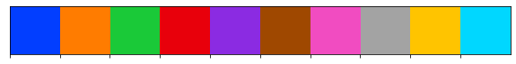

```python
# Save a palette to a variable
palette = sb.color_palette('bright')
# Use palplot and pass in the variable
sb.palplot(palette)
```

```python
# Use 'tab10', These colors have the same ordering as the default matplotlib color palette,but they are a bit less intense.
sb.color_palette("tab10")
```

[output not shown]

```python
sb.color_palette("Paired")
```

[output not shown]

**Resources:**

- Udacity Classroom, Lesson 3: Univariate Exploration of Data.
- Use the documentation Website, `General principles for using color in plots`, and the `componets of color`.
- Use the documentation [Website](https://www.codecademy.com/articles/seaborn-design-ii), `Commands for Working with Palettes`.

#### Plotting 'start_time_hour' feature

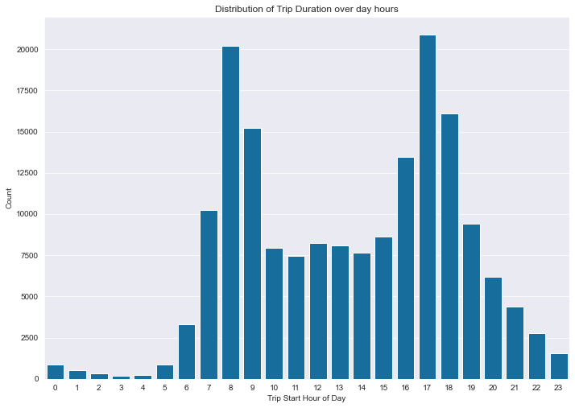

```python
# The distribution of the trip duration over day hours
# Use seaborn.color_palette() function to return a list of color or continuous colormap defining a palette.
base_color = sb.color_palette('colorblind')[0]
# Use seaborn.set_style() function to set aesthetic style of the plots
sb.set_style('darkgrid')
# Use matplotlib.figure() function to control the default spacing of the subplots and the top level container of the subplots,
# and the top level container for all plot elements.
plt.figure(figsize=[ 11.69, 8.27])
# Use matplotlib.pyplot.title() to set a title for the axes.
plt.title('Distribution of Trip Duration over day hours')
# Use seaborn.countplot() function to show the counts of observations in each categorical bin using bars.
sb.countplot(data=df, x='start_time_hour', color=base_color);
# Use matplotlib.pyplot.xlabel to set the label for the x-axis.
plt.xlabel('Trip Start Hour of Day');
# Use matplotlib.pyplot.ylabel to set the label for the y-axis.
plt.ylabel('Count');
```

**Observation**

- From the start time hour, the time 8:00 AM and 5:00 PM are the two peak hours which have most bikers, followed by 9:00 AM and 6:00 PM.

#### Plotting 'start_time_dayofweek' feature

```python
df['start_time_dayofweek'].value_counts()
```

```
Thu    33712
Tue    30584
Wed    28426
Fri    27663
Mon    25641
Sun    14512
Sat    14414
Name: start_time_dayofweek, dtype: int64
```

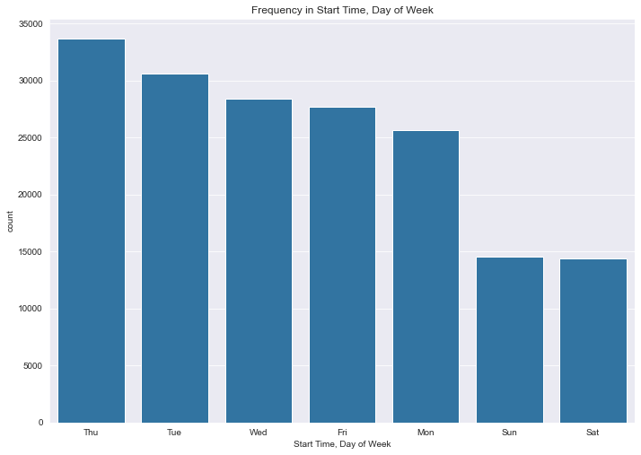

```python
# Duratuion Trip over the day of the week
# Use seaborn.color_palette() function to return a list of color or continuous colormap defining a palette.
default_color = sb.color_palette()[0]
dayofweek_order = df['start_time_dayofweek'].value_counts().index
# Use matplotlib.figure() function to control the default spacing of the subplots and the top level container of the subplots,
# and the top level container for all plot elements.
plt.figure(figsize=[ 11.69, 8.27])
# Use seaborn.countplot()** function to show the counts of observations in each categorical bin using bars.
sb.countplot(data = df, x = 'start_time_dayofweek', color = default_color, order=dayofweek_order);
# Use matplotlib.pyplot.title to set a title for the axes.
plt.title('Frequency in Start Time, Day of Week');
# Use matplotlib.pyplot.xlabel to set the label for the x-axis.
plt.xlabel('Start Time, Day of Week');
```

**Observation**

- Thursday has the most bikers with counts of 33,712 of unique values compared to other days.
- However, Saturday has the lowest number of bikers with counts of 14,414 of unique values.

```python
df['user_type'].value_counts()
```

```
Subscriber    158386
Customer       16566
Name: user_type, dtype: int64
```

```python
df['user_type'].value_counts(normalize=True)
```

```
Subscriber    0.905311
Customer      0.094689
Name: user_type, dtype: float64
```

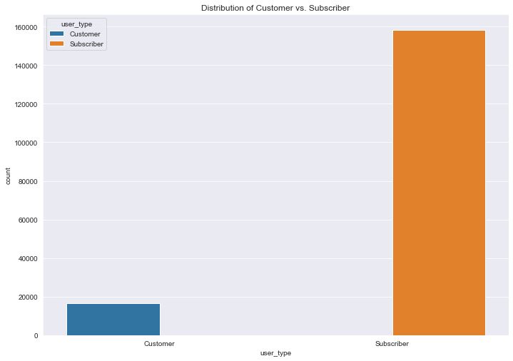

```python
# count plot on single categorical variable

# Use matplotlib.figure() function to control the default spacing of the subplots and the top level container of the subplots,
# and the top level container for all plot elements.
plt.figure(figsize=[ 11.69, 8.27])
# Use matplotlib.pyplot.title() to set a title for the axes.
plt.title('Distribution of Customer vs. Subscriber')
# Use seaborn.countplot()** function to show the counts of observations in each categorical bin using bars.
sb.countplot(x ='user_type',hue='user_type', data = df)
# Use matplotlib.pyplot.show() function to display all figures.
plt.show();
```

**Observation**

- The subscriber has the highest number 158,386 of the unique values of the user type.
- The customer has the lowest numver 16,566 of the unique values of the user type.
- The subscriber and customer are representing approximately 90% and 10% of the user type, repectively.

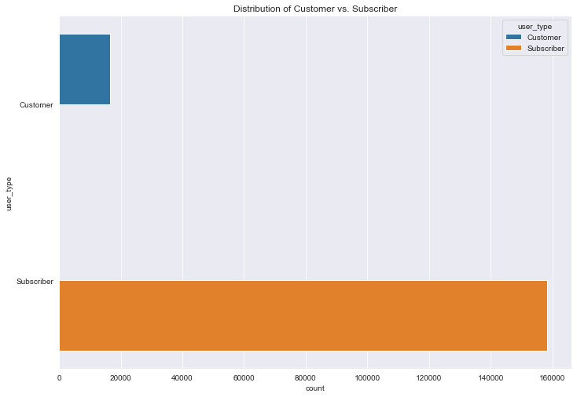

```python
# count plot on single categorical variable

# Use matplotlib.figure() function to control the default spacing of the subplots and the top level container of the subplots,
# and the top level container for all plot elements.
plt.figure(figsize=[ 11.69, 8.27])
# Use matplotlib.pyplot.title() to set a title for the axes.
plt.title('Distribution of Customer vs. Subscriber')
# Use seaborn.countplot()** function to show the counts of observations in each categorical bin using bars.
# count plot along y axis
sb.countplot(y ='user_type', hue='user_type', data = df)
# Use matplotlib.pyplot.show() function to display all figures.
plt.show();
```

**Observation**

- The subscriber has the highest number 158,386 of the unique values of the user type.
- The customer has the lowest numver 16,566 of the unique values of the user type.
- The subscriber and customer are representing approximately 90% and 10% of the user type, repectively.

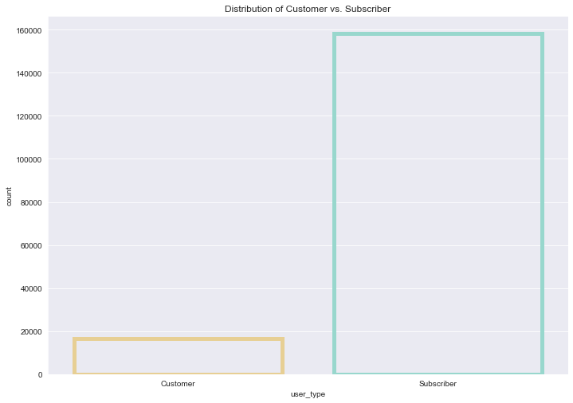

```python
# count plot on single categorical variable

# Use matplotlib.figure() function to control the default spacing of the subplots and the top level container of the subplots,
# and the top level container for all plot elements.
plt.figure(figsize=[ 11.69, 8.27])
# Use matplotlib.pyplot.title() to set a title for the axes.
plt.title('Distribution of Customer vs. Subscriber')
# Use seaborn.countplot()** function to show the counts of observations in each categorical bin using bars.
sb.countplot(x ='user_type', data = df, color="salmon", facecolor=(0,0,0,0), linewidth=5, edgecolor=sb.color_palette('BrBG',2))
# Use matplotlib.pyplot.show() function to display all figures.
plt.show();
```

**Observation**

- The subscriber has the highest number 158,386 of the unique values of the user type.
- The customer has the lowest numver 16,566 of the unique values of the user type.
- The subscriber and customer are representing approximately 90% and 10% of the user type, repectively.

**Resources:**

- Udacity Classroom, Lesson 3: Univariate Exploration of Data.
- Use the documentation [Website](https://seaborn.pydata.org/generated/seaborn.countplot.html?highlight=seaborn%20countplot#seaborn.countplot), Use **seaborn.countplot()** function to show the counts of observations in each categorical bin using bars.
- Use the documentation [Website](https://www.geeksforgeeks.org/countplot-using-seaborn-in-python/), Use a different color palette in count plot, and use matplotlib.axes.Axes.bar() parameters to control the style.
- Use the documentation [Website](https://stackoverflow.com/questions/33179122/seaborn-countplot-with-frequencies), Use seaborn.countplot() function with frequencies.
- Use the documentation [Website](https://towardsdatascience.com/hands-on-python-data-visualization-seaborn-count-plot-90e823599012) Create a simple count plot for a single categorical variable.

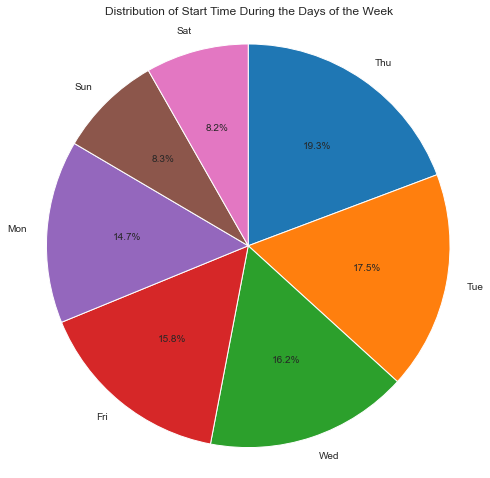

```python
# the Distribution of Start Time, Day of week
# Pie chart, where the slices will be ordered and plotted counter-clockwise:
sorted_counts = df['start_time_dayofweek'].value_counts()
# Use matplotlib.figure() function to control the default spacing of the subplots and the top level container of the subplots,
# and the top level container for all plot elements.
plt.figure(figsize=[ 11.69, 8.27])
# Use matplotlib.pyplot.title() to set a title for the axes.
plt.title('Distribution of Start Time During the Days of the Week')
# Use matplotlib.pyplot.pie() function to plot a pie chart
plt.pie(sorted_counts, labels = sorted_counts.index, startangle = 90, counterclock = False, autopct='%1.1f%%');
# Use matplotlib.pyplot.axis('square') to create a square plot with equal axes
plt.axis('square');
```

**Observation**

- From the days of the week, Thursday has the most bikers, compared to other days, with a percentage of 19.3%.
- However, Saturday has the lowest number of bikers, with a percentage of 8.2%.

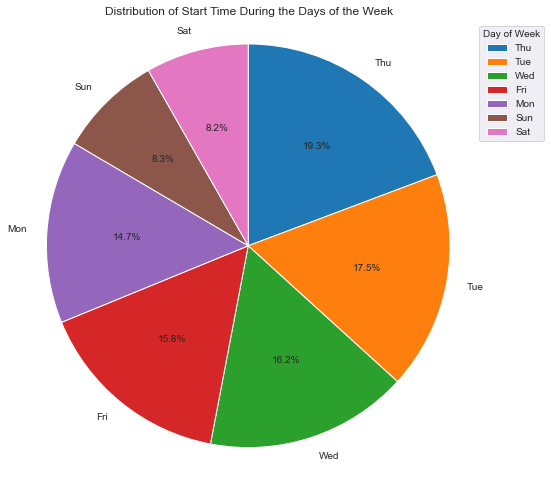

```python
# the Distribution of Start Time, Day of week
# Pie chart, where the slices will be ordered and plotted counter-clockwise:
sorted_counts = df['start_time_dayofweek'].value_counts()
# Use matplotlib.figure() function to control the default spacing of the subplots and the top level container of the subplots,
# and the top level container for all plot elements.
plt.figure(figsize=[ 11.69, 8.27])
# Use matplotlib.pyplot.title() to set a title for the axes.
plt.title('Distribution of Start Time During the Days of the Week')
# Use matplotlib.pyplot.pie() function to plot a pie chart
plt.pie(sorted_counts, labels = sorted_counts.index, startangle = 90, counterclock = False, autopct='%1.1f%%');
# Use matplotlib.pyplot.axis('square') to create a square plot with equal axes
plt.axis('square');
# Use matplotlib.pyplot.legend() function to place a legend on the axes
plt.legend(title ="Day of Week",loc ="upper left",bbox_to_anchor =(1, 0, 0.5, 1));
# Use matplotlib.pyplot.show() function to display all figures.
plt.show();
```

**Observation**

- From the days of the week, Thursday has the most bikers, compared to other days, with a percentage of 19.3%.
- However, Saturday has the lowest number of bikers, with a percentage of 8.2%.

**Resources:**

- Udacity Classroom, Lesson 3: Univariate Exploration of Data.
- Use the documentation [Website](https://matplotlib.org/api/_as_gen/matplotlib.pyplot.pie.html?highlight=pie#matplotlib.pyplot.pie), Use **matplotlib.pyplot.pie()** function to plot a pie chart.
- Use the documentation [Website](https://www.geeksforgeeks.org/plot-a-pie-chart-in-python-using-matplotlib/), Plot a pie chart in Python using Matplotlib.
- Use the documentation [Website](https://www.tutorialspoint.com/matplotlib/matplotlib_pie_chart.htm), matplotlib - Pie chart.

**Donut Plot**

- A sister plot to the pie chart is the donut plot. It's just like a pie chart, except that there's a hole in the center of the plot. Perceptually, there's not much difference between a donut plot and a pie chart, and donut plots should be used with the same guidelines as a pie chart. Aesthetics might be one of the reasons why you would choose one or the other. For instance, you might see statistics reported in the hole of a donut plot to better make use of available space.
- To create a donut plot, you can add a wedgeprops argument to the pie function call. By default, the radius of the pie (circle) is 1; setting the wedges' width property to less than 1 removes coloring from the center of the circle.

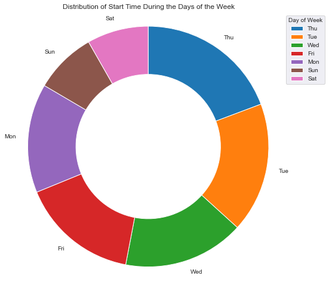

```python
sorted_counts = df['start_time_dayofweek'].value_counts()
# Use matplotlib.figure() function to control the default spacing of the subplots and the top level container of the subplots,
# and the top level container for all plot elements.
plt.figure(figsize=[ 11.69, 8.27])
# Use matplotlib.pyplot.title() to set a title for the axes.
plt.title('Distribution of Start Time During the Days of the Week')
# Use matplotlib.pyplot.pie() function to plot a pie chart, with this parameters to create the donut plot.
plt.pie(sorted_counts, labels = sorted_counts.index, startangle = 90, counterclock = False, wedgeprops = {'width' : 0.4});
# Use matplotlib.pyplot.axis('square') to create a square plot with equal axes
plt.axis('square');
# Use matplotlib.pyplot.legend() function to place a legend on the axes
plt.legend(title ="Day of Week",loc ="upper left",bbox_to_anchor =(1, 0, 0.5, 1));
# Use matplotlib.pyplot.show() function to display all figures.
plt.show();
```

**Observation**

From the days of the week, Thursday has the most bikers, compared to other days.

**Resources:**

- Udacity Classroom, Lesson 3: Univariate Exploration of Data.
- Use the documentation [Website](https://matplotlib.org/api/_as_gen/matplotlib.pyplot.pie.html?highlight=pie#matplotlib.pyplot.pie), Use **matplotlib.pyplot.pie()** function to plot a pie chart (Donut Plot).
- Use the documentation [Website](https://python-graph-gallery.com/donut-plot/), Plot a Pie chart (Donut plot) in Python using Matplotlib, A Python Graph Gallery.
- Use the documentation [Website](https://medium.com/@kvnamipara/a-better-visualisation-of-pie-charts-by-matplotlib-935b7667d77f), A better visualization of pie charts by matplotlib.

#### Plotting 'duration_min' feature

```python
df[['duration_sec','duration_min']].describe()
```

|  | duration_sec | duration_min |
| --- | --- | --- |
| count | 174952.000000 | 174952.000000 |
| mean | 704.002744 | 11.733379 |
| std | 1642.204905 | 27.370082 |
| min | 61.000000 | 1.016667 |
| 25% | 323.000000 | 5.383333 |
| 50% | 510.000000 | 8.500000 |
| 75% | 789.000000 | 13.150000 |
| max | 84548.000000 | 1409.133333 |

**Histogram**

- A `Histogram` is used to plot the distribution of a numeric varible. It is the quantitative version of bar chart.
- However, rather than plot one bar for each unique numberic value, values are grouped into continuous bins, and one bar for each bin is plotted to depict the number.
- A `histogram` tells you how many observations or data points fall in various ranges of values.
- Use `Matplotlib.pyplot.hist()` function to create `histograms`.
- However, a `histogram` shows the frequency on the vertical axis and the horizontal axis is another dimension. Usually it has bins, where every bin has a minimum and maximum value. Each bin also has a frequency between x and infinite.

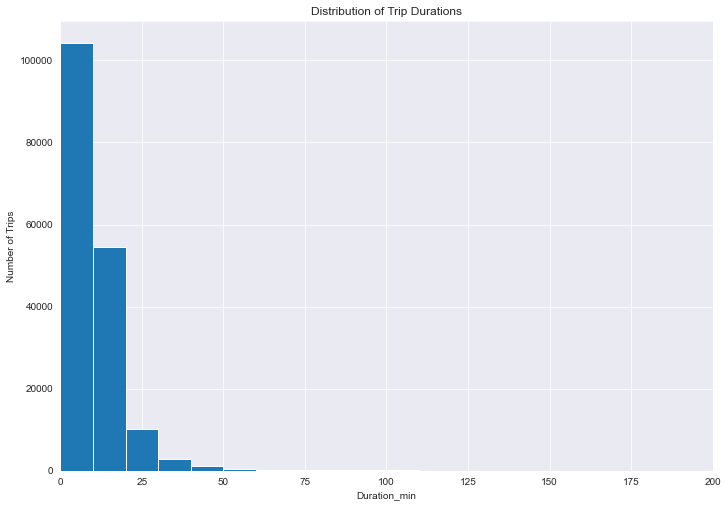

```python
# The Distribution of Trip Duration, in Minutes

# Set the bins, where the bin has a minimum value and maximum value.
bins = np.arange(0, df['duration_min'].max()+10, 10)
# Use matplotlib.figure() function to control the default spacing of the subplots and the top level container of the subplots,
# and the top level container for all plot elements.
plt.figure(figsize=[ 11.69, 8.27])
# Use matplotlib.pyplot.hist() function to plot a histogram.
plt.hist(data = df, x = 'duration_min', bins = bins)
# Use matplotlib.pyplot.title() to set a title for the axes.
plt.title('Distribution of Trip Durations')
# Use matplotlib.pyplot.xlabel to set the label for the x-axis.
plt.xlabel('Duration_min')
# Use matplotlib.pyplot.ylabel to set the label for the y-axis.
plt.ylabel('Number of Trips')
# Use matplotlib.pyplot.xlim() function to get or set the x limits of the current axes.
plt.xlim((0,200));
# Use matplotlib.pyplot.show () function to display all open figures.
plt.show();
```

**Observation**

**Resources:**

- Udacity Classroom, Lesson 3: Univariate Exploration of Data, 8.Histograms.
- Use the documentation [Website](https://matplotlib.org/api/_as_gen/matplotlib.pyplot.hist.html?highlight=hist#matplotlib.pyplot.hist), Use **matplotlib.pyplot.hist()** function to plot a histogram.
- Use the documentation [Website](https://www.geeksforgeeks.org/matplotlib-pyplot-hist-in-python/), Matplotlib.pyplot.hist() in Python.
- Use the documentation [Website](https://stackoverflow.com/questions/6986986/bin-size-in-matplotlib-histogram), Bin size in Matplotlib (Histogram).

**Bell-shape Curve**

- A bell curve is a common type of distribution for a variable, also known as the normal distribution.
- The term "bell curve" originates from the fact that the graph used to depict a normal distribution consists of a symmetrical bell-shaped curve.
- The highest point on the curve, or the top of the bell, represents the most probable event in a series of data (its mean, mode, and median in this case), while all other possible occurrences are symmetrically distributed around the mean, creating a downward-sloping curve on each side of the peak. The width of the bell curve is described by its standard deviation.
- A bell curve is a graph depicting the normal distribution, which has a shape reminiscent of a bell.
- The top of the curve shows the mean, mode, and median of the data collected.
- Its standard deviation depicts the bell curve's relative width around the mean.

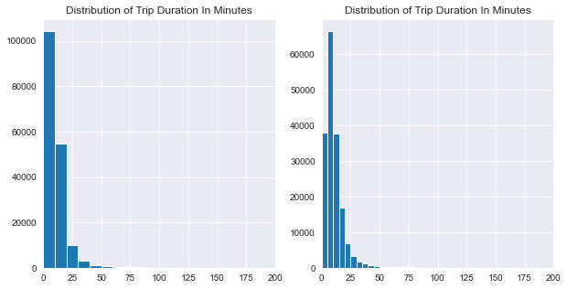

```python
# Plot two histograms side-by-side by using matplotlib.pyplot.subplot() function
# Resize the chart, and have two plots side-by-side
# Set a larger figure size for subplots
plt.figure(figsize = [10, 5])

# Use matplotlib.pyplot.subplot() function to add a subplot to the current figure.
# histogram on left, example of too-large bin size
# 1 row, 2 cols, subplot 1
plt.subplot(1, 2, 1)
bins = np.arange(0, df['duration_min'].max()+10, 10)
# Use matplotlib.pyplot.title() to set a title for the axes.
plt.title('Distribution of Trip Duration In Minutes')
plt.hist(data = df, x = 'duration_min', bins = bins);
plt.xlim((0,200));

# histogram on right, example of too-small bin size
# 1 row, 2 cols, subplot 2
plt.subplot(1, 2, 2)
bins = np.arange(0, df['duration_min'].max()+5, 5)
# Use matplotlib.pyplot.title() to set a title for the axes.
plt.title('Distribution of Trip Duration In Minutes')
plt.hist(data = df, x = 'duration_min', bins = bins);
plt.xlim((0,200));
```

**Observation**

**Resources:**

- Udacity Classroom, Lesson 3: Univariate Exploration of Data, 8.Histograms.
- Udacity classroom, Lesson 4: Bivariate Exploration of Data.
- Use the documentation [Website](https://matplotlib.org/api/_as_gen/matplotlib.pyplot.subplot.html?highlight=subplot#matplotlib.pyplot.subplot), Use **matplotlib.pyplot.subplot()** function to dd a subplot to the current figure.
- Use the documentation [Website](https://stackoverflow.com/questions/31726643/how-do-i-get-multiple-subplots-in-matplotlib), Get Multiple Subplots in Matplotlib.

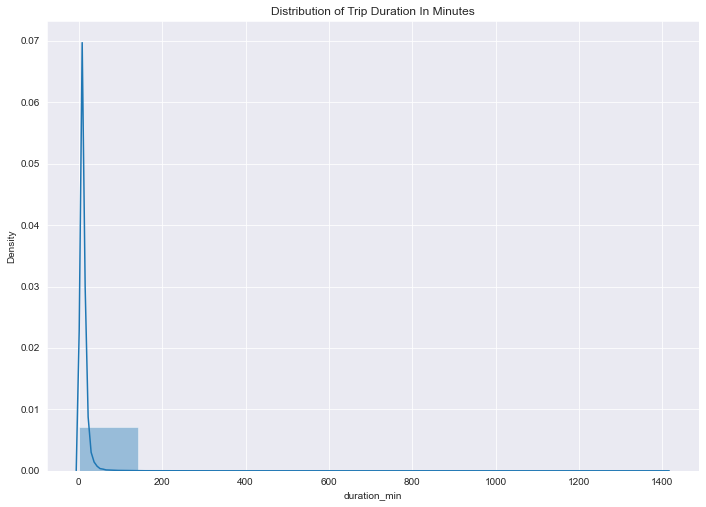

```python
# Seaborn Distribution of Trip Duration

# Use matplotlib.figure() function to control the default spacing of the subplots and the top level container of the subplots,
# and the top level container for all plot elements.
plt.figure(figsize=[ 11.69, 8.27])
# Use matplotlib.pyplot.title() to set a title for the axes.
plt.title('Distribution of Trip Duration In Minutes')
# Use seaborn.distplot() function to fexibly plot a univariate distribution of observations.
sb.distplot(df['duration_min'], bins=10)
plt.show();
```

**Observation**

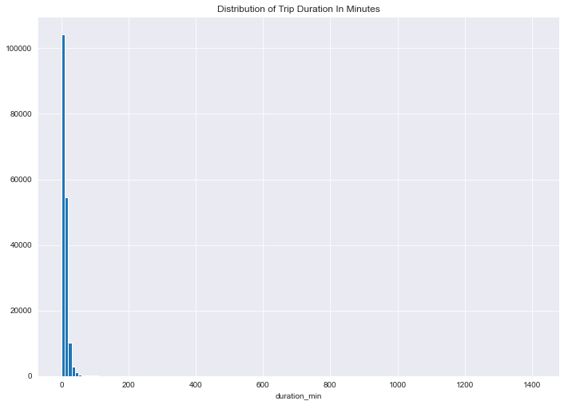

```python
# Set bins
bin_edges = np.arange(0, df['duration_min'].max()+10, 10)

# Use matplotlib.figure() function to control the default spacing of the subplots and the top level container of the subplots,
# and the top level container for all plot elements.
plt.figure(figsize=[ 11.69, 8.27]);
# Use matplotlib.pyplot.title() to set a title for the axes.
plt.title('Distribution of Trip Duration In Minutes');
# Use seaborn.distplot() function to fexibly plot a univariate distribution of observations
sb.distplot(df['duration_min'], bins = bin_edges, kde = False, hist_kws = {'alpha' : 1});
```

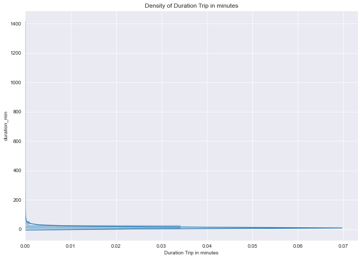

```python
# Plot the distribution of the Trip Duration on the vertical axis:

# Use matplotlib.figure() function to control the default spacing of the subplots and the top level container of the subplots,
# and the top level container for all plot elements.
plt.figure(figsize=[ 11.69, 8.27])
# Use seaborn.distplot() function to fexibly plot a univariate distribution of observations
sb.distplot(df['duration_min'], vertical=True)

plt.title('Density of Duration Trip in minutes');
plt.xlabel('Duration Trip in minutes');
```

**Resources:**

- Udacity Classroom, Lesson 3: Univariate Exploration of Data, 8.Histogram.
- Use the documentation [Website](https://seaborn.pydata.org/generated/seaborn.distplot.html?highlight=distplot#seaborn.distplot), Use **seaborn.distplot()** function to flexibly plot a univariate distribution of observations.
- Use the documentation [Website](https://pythonbasics.org/seaborn-distplot/), Seaborn Distplot.
- Use the documentation [Website](https://datascience.stackexchange.com/questions/66528/seaborn-distplot-and-kde-data-confusion), Seaborn distplot and KDE data confusion.

**Violin Plots**

- There are a few ways of plotting the relationship between one quantitative and one qualitative variable, that demonstrate the data at different levels of abstraction. The violin plot is on the lower level of abstraction.
- For each level of the categorical variable, a distribution of the values on the numeric variable is plotted.
- The distribution is plotted as a kernel density estimate, something like a smoothed histogram.
- Seaborn's violinplot() function can be used to create violin plots, or to draw a combination of boxplot and kernel density estimate.

```python
df.duration_min.describe()
```

```
count    174952.000000
mean         11.733379
std          27.370082
min           1.016667
25%           5.383333
50%           8.500000
75%          13.150000
max        1409.133333
Name: duration_min, dtype: float64
```

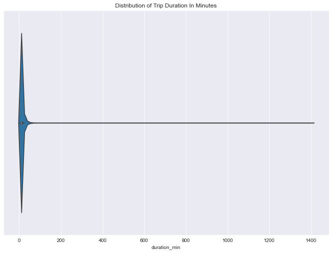

```python
# Use matplotlib.figure() function to control the default spacing of the subplots and the top level container of the subplots,
# and the top level container for all plot elements.
plt.figure(figsize=[ 11.69, 8.27])
# Use matplotlib.pyplot.title() to set a title for the axes.
plt.title('Distribution of Trip Duration In Minutes');
# Use seaborn.violinplot() function to draw a combination of boxplot and kernel density estimate
sb.violinplot(data = df, x = 'duration_min');
```

**Observation**

- The maximum value and the minimum value of trip duration in minutes are 1409.13 minutes and 1.016 minutes, respectively.

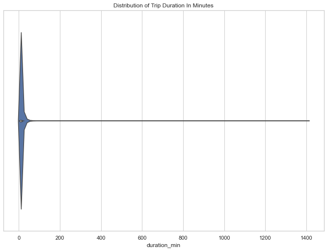

```python
# Use matplotlib.figure() function to control the default spacing of the subplots and the top level container of the subplots,
# and the top level container for all plot elements.
plt.figure(figsize=[ 11.69, 8.27])
# Use seaborn.set() function to set the aesthetic style of the plots.
sb.set(style = 'whitegrid')
# Use matplotlib.pyplot.title() to set a title for the axes.
plt.title('Distribution of Trip Duration In Minutes')
# Use seaborn.violinplot() function to draw a combination of boxplot and kernel density estimate.
sb.violinplot(data = df, x = 'duration_min');
```

**Observation**

- The maximum value and the minimum value of trip duration in minutes are 1409.13 minutes and 1.016 minutes, respectively.

**Resources:**

- Udacity Classroom, Lesson 4: Bivariate Exploration of Data, 6.Violinplot.
- Use the documentation [Website](https://seaborn.pydata.org/generated/seaborn.violinplot.html?highlight=violin#seaborn.violinplot), Use **seaborn.violinplot()** function to to draw a combination of boxplot and kernel density estimate.
- Use the documentation [Website](https://www.geeksforgeeks.org/violinplot-using-seaborn-in-python/), Violinplot Using Seaborn in Python.
- Use the documentation [Website](https://stackabuse.com/seaborn-violin-plot-tutorial-and-examples/), Seaborn Violinplot, Tutorial and Examples.

#### Plotting 'member age' feature

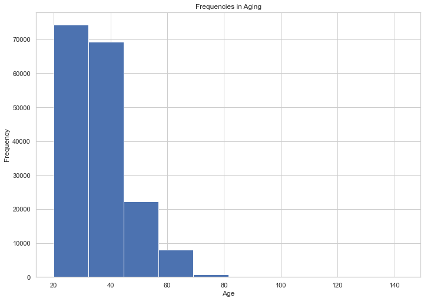

```python
# plot the distribution of the member age

# Use matplotlib.figure() function to control the default spacing of the subplots and the top level container of the subplots,
# and the top level container for all plot elements.
plt.figure(figsize=[ 11.69, 8.27]);
# Use matplotlib.pyplot.hist() to plot a historgram.
plt.hist(data=df, x='member_age');
# Use matplotlib.pyplot.xlabel to set the label for the x-axis.
plt.xlabel('Age');
# Use matplotlib.pyplot.ylabel to set the label for the y-axis.
plt.ylabel('Frequency');
# Use matplotlib.pyplot.title() to set a title for the axes.
plt.title('Frequencies in Aging');
# Use matplotlib.pyplot.show () function to display all open figures.
plt.show();
```

**Observation**

- The most bikers are between 25 to 40 years old.

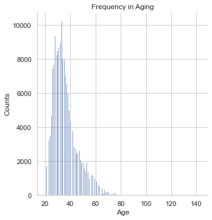

```python
# Ploting the Distribution of the bikers' age

# Use matplotlib.figure() function to control the default spacing of the subplots and the top level container of the subplots,
# and the top level container for all plot elements.
plt.figure(figsize=[ 11.69, 8.27])
# Use seaborn.distplot() function to felxibly plot a univariate distribution of observation
sb.displot(df['member_age'], kind='hist');
# Use matplotlib.pyplot.title() to set a title for the axes.
plt.title('Frequency in Aging');
# Use matplotlib.pyplot.xlabel to set the label for the x-axis
plt.xlabel('Age');
# Use matplotlib.pyplot.ylabel to set the label for the y-axis.
plt.ylabel('Counts');
# Use matplotlib.pyplot.show () function to display all open figures.
plt.show();
```

**Observation**

- The most bikers are between 25 to 40 years old.

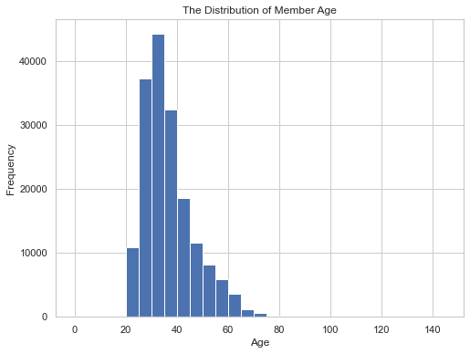

```python
# plot the distribution of the bikers' age

# Use matplotlib.figure() function to control the default spacing of the subplots and the top level container of the subplots,
# and the top level container for all plot elements.
plt.figure(figsize=[8, 6])
# Set bins
bins = np.arange(0, df['member_age'].max()+5, 5)
# Use matplotlib.pyplot.hist() function to plot a histogram.
plt.hist(data=df, x='member_age', bins=bins);
# Use matplotlib.pyplot.title() to set a title for the axes.
plt.title('The Distribution of Member Age');
# Use matplotlib.pyplot.xlabel to set the label for the x-axis
plt.xlabel('Age');
# Use matplotlib.pyplot.ylabel to set the label for the y-axis.
plt.ylabel('Frequency');
# Use matplotlib.pyplot.show () function to display all open figures.
plt.show();
```

**Observation**

The most bikers are between 25 to 40 years old.

**Boxplots**

- A box plot is another way of showing the relationship between a numeric variable and a categorical variable.
- Compared to the violin plot, the box plot leans more on the summarization of the data, primarily just reporting a set of descriptive statistics for the numeric values on each categorical level.
- A box plot can be created using seaborn's boxplot() function.
- A boxplot, also called a box and whisker plot, is a way to show the spread and centers of a data set.
- Measures of spread include the interquartile range and the mean of the data set.
- Measures of center include the mean or average and median (the middle of a data set).
- Five pieces of information (the “five number summary“) are generally included in the chart:
- The minimum (the smallest number in the data set) is shown at the far down of the chart, at the end of the down “whisker.”
- First quartile, Q1, is the far down of the box (or the far end of the down whisker).
- The median is shown as a line in the center of the box.
- Third quartile, Q3, shown at the far upper of the box (at the far upper of the upper whisker).
- The maximum (the largest number in the data set), shown at the far upper of the box.
- If your data set has outliers, the box and whiskers chart may not show the minimum or maximum value. Instead, the ends of the whiskers represent one and a half times the interquartile range (1.5*IQR).

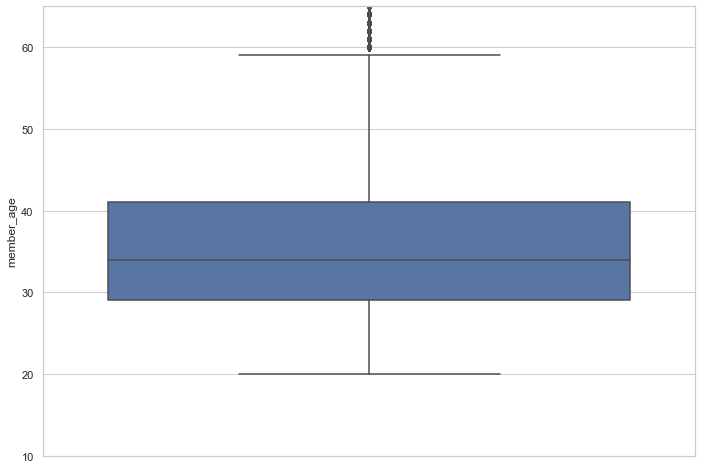

```python
# Draw a single vartical boxplot:

# Use matplotlib.figure() function to control the default spacing of the subplots and the top level container of the subplots,
# and the top level container for all plot elements.
plt.figure(figsize=[ 11.69, 8.27]);
# Use matplotlib.pyplot.ylim() function to get or set the y-limits of the current axes
plt.ylim([10,65]);
# Use seaborn.boxplot() function to draw a box plot to show distributions with respect to categories
sb.boxplot(data = df, y = 'member_age');
```

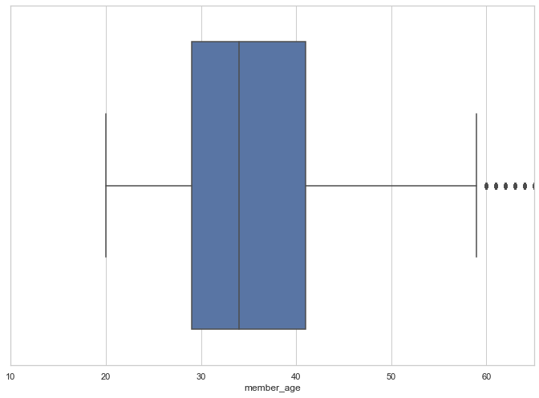

```python
# Draw a single Horizontal boxplot:

# Use matplotlib.figure() function to control the default spacing of the subplots and the top level container of the subplots,
# and the top level container for all plot elements.
plt.figure(figsize=[ 11.69, 8.27]);
# Use matplotlib.pyplot.xlim() function to get or set the x-limits of the current axes
plt.xlim([10,65]);
# Use seaborn.boxplot() function to draw a box plot to show distributions with respect to categories
sb.boxplot(data = df, x = 'member_age');
```

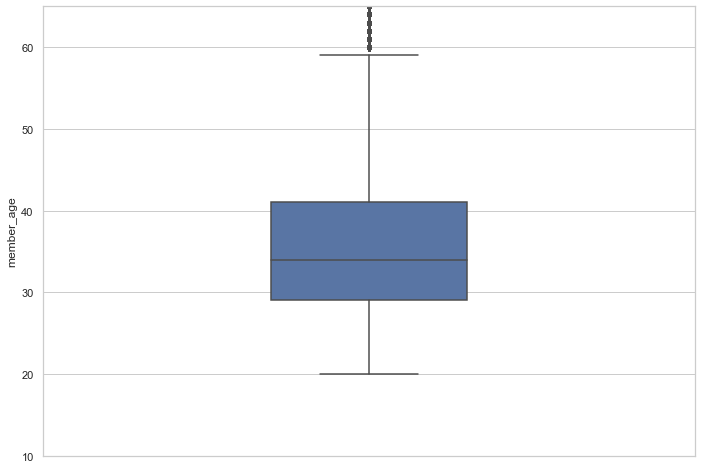

```python
# Draw a single vartical boxplot:

# Use matplotlib.figure() function to control the default spacing of the subplots and the top level container of the subplots,
# and the top level container for all plot elements.
plt.figure(figsize=[ 11.69, 8.27])
# Use matplotlib.pyplot.ylim() function to get or set the y-limits of the current axes
plt.ylim([10,65]);
# Use seaborn.boxplot() function to draw a box plot to show distributions with respect to categories
sb.boxplot(data = df, y = 'member_age', width=.3);
```

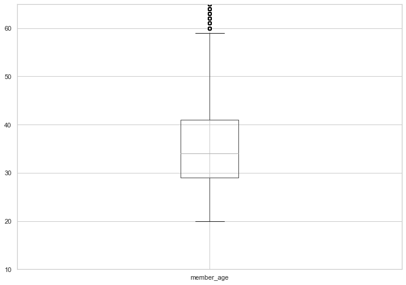

```python
# Draw a single vartical boxplot of member age"

# Use matplotlib.figure() function to control the default spacing of the subplots and the top level container of the subplots,
# and the top level container for all plot elements.
plt.figure(figsize=[ 11.69, 8.27]);
# Use matplotlib.pyplot.ylim() function to get or set the y-limits of the current axes
plt.ylim([10,65]);
# Use pandas.DataFrame.boxplot() function to make a box plot from DataFrame columns.
df.boxplot(column =['member_age']);
```

**Resources:**

- Udacity classroom, Lesson 4: Bivariate Exploration of Data.
- Use the documentation [Website](https://seaborn.pydata.org/generated/seaborn.boxplot.html?highlight=boxplot#seaborn.boxplot), Use **seaborn.boxplot()** function to draw a box plot to show distributions with respect to categories.
- Use the documentation [Website](https://pythonbasics.org/seaborn-boxplot/), Seaborn Boxplot.
- Use the documentation [Website](https://www.geeksforgeeks.org/box-plot-visualization-with-pandas-and-seaborn/), Box Plot Visualization with Pandas and Seaborn.

```python
df['member_age'].describe()
```

```
count    174952.000000
mean         36.196865
std          10.118731
min          20.000000
25%          29.000000
50%          34.000000
75%          41.000000
max         143.000000
Name: member_age, dtype: float64
```

- It is unusual that the maximum member age is 143 years.
- The data is not distributed evenly, so let's calculate the Interquartile Range (IQR).
- IQR = Q3 - Q1 = 41 - 29 = 12.
- Upper Wisker Bound = (1.5 * IQR) + Q3 = 59.

```python
# Remove the outliers
df = df[df['member_age'] <= 60]
```

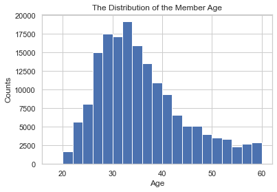

```python
# plot the distribution of the bikers' age

# Set bins (A histogram displays numerical data by grouping data into "bins" of equal width.)
bins = np.arange(18, df['member_age'].max()+2, 2)

# Use matplotlib.pyplot.hist() function to plot a histogram.
plt.hist(data = df, x = 'member_age', bins = bins);

# Use matplotlib.pyplot.title() to set a title for the axes.
plt.title('The Distribution of the Member Age');
# Use matplotlib.pyplot.xlabel to set the label for the x-axis
plt.xlabel('Age');
# Use matplotlib.pyplot.ylabel to set the label for the y-axis.
plt.ylabel('Counts');
# Use matplotlib.pyplot.show () function to display all open figures.
plt.show();
```

#### Plotting 'member_birth_year' feature

```python
df['member_birth_year'].describe()
```

```
count    169992.000000
mean       1985.694597
std           8.669889
min        1961.000000
25%        1981.000000
50%        1987.000000
75%        1992.000000
max        2001.000000
Name: member_birth_year, dtype: float64
```

[figure not shown]

```python
# Plotting distribution of age derived from member's birth year.

# Set bins (A histogram displays numerical data by grouping data into "bins" of equal width)
bins = np.arange(0, df['member_birth_year'].astype(float).max()+.50, .50)
# Use matplotlib.figure() function to control the default spacing of the subplots and the top level container of the subplots,
# and the top level container for all plot elements.
plt.figure(figsize=[8, 5])
# Use matplotlib.pyplot.hist() function to plot a histogram.
plt.hist(data = df, x = 'member_birth_year', bins = bins)
# Use matplotlib.pyplot.axis() function to get or set properties of x-axis and y-axis.
plt.axis([1961, 2001, 0, 12000])
# Use matplotlib.pyplot.xticks() function to get or set the current tick locations and labels of the x-axis.
plt.xticks([1961, 1971, 1981, 1991, 2001], [(2001-1961), (2001-1971), (2001-1981), (2001-1991),(2021-2001)])
# Use matplotlib.pyplot.gca() function to get the current axes, creating one if necessary,
# and invert_xaxis() to reverse x-axes.
plt.gca().invert_xaxis()
# Use matplotlib.pyplot.title() to set a title for the axes.
plt.title('Distribution of User Age')
# Use matplotlib.pyplot.xlabel to set the label for the x-axis
plt.xlabel('Age')
# Use matplotlib.pyplot.ylabel to set the label for the y-axis.
plt.ylabel('Number of Users')
# Use matplotlib.pyplot.show () function to display all open figures.
plt.show();
```

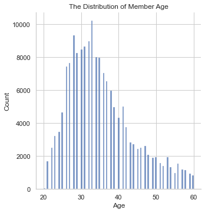

```python
# Use seaborn.distplot() function to felxibly plot a univariate distribution of observation
sb.displot(df['member_age'], kind='hist');

# Use matplotlib.pyplot.title() to set a title for the axes.
plt.title('The Distribution of Member Age');
# Use matplotlib.pyplot.xlabel to set the label for the x-axis.
plt.xlabel('Age');
# Use matplotlib.pyplot.ylabel to set the label for the y-axis.
plt.ylabel('Count');
# Use matplotlib.pyplot.show () function to display all open figures.
plt.show();
```

**Observation**

- The most bikers are between 25 to 40 years old.

#### Plotting 'user_type' feature

```python
df['user_type'].value_counts()
```

```
Subscriber    153736
Customer       16256
Name: user_type, dtype: int64
```

```python
df['user_type'].value_counts(normalize=True)
```

```
Subscriber    0.904372
Customer      0.095628
Name: user_type, dtype: float64
```

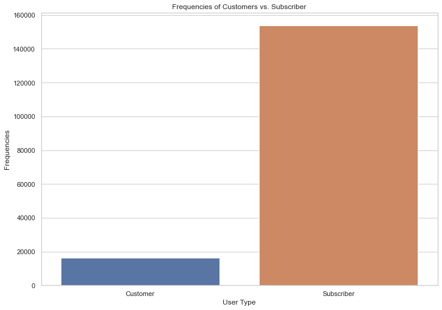

```python
# Plot the distribution of both Customers and Subscribers

# Use matplotlib.figure() function to control the default spacing of the subplots and the top level container of the subplots,
# and the top level container for all plot elements.
plt.figure(figsize=[ 11.69, 8.27])
# Use seaborn.countplot() function to show the counts of observations in each categorical bin using bars
sb.countplot(data=df, x='user_type');

# Use matplotlib.pyplot.title to set a title for the axes.
plt.title('Frequencies of Customers vs. Subscriber');
# Use matplotlib.pyplot.title to set a title for the axes.
plt.xlabel('User Type');
# Use matplotlib.pyplot.ylabel to set the label for the y-axis.
plt.ylabel('Frequencies');
# Use matplotlib.pyplot.show () function to display all open figures.
plt.show();
```

**Observation**

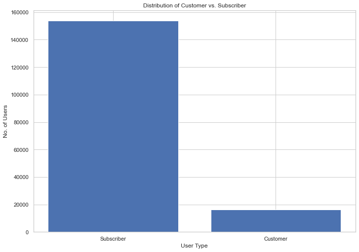

```python
# plotting types of users
plt.figure(figsize=[ 11.69, 8.27])
plt.bar(x = df.user_type.value_counts().keys(), height = df.user_type.value_counts())

# Use matplotlib.pyplot.title to set a title for the axes.
plt.title('Distribution of Customer vs. Subscriber');
# Use matplotlib.pyplot.title to set a title for the axes.
plt.xlabel('User Type');
# Use matplotlib.pyplot.ylabel to set the label for the y-axis.
plt.ylabel('No. of Users');
# Use matplotlib.pyplot.show () function to display all open figures.
plt.show();
```

**Observation**

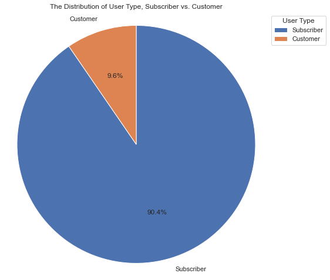

```python
# Plot the distribution of user type
# Use matplotlib.pyplot.pie() function to plot a pie chart
sorted_counts = df['user_type'].value_counts()
# Use matplotlib.figure() function to control the default spacing of the subplots and the top level container of the subplots,
# and the top level container for all plot elements.
plt.figure(figsize=[ 11.69, 8.27]);
# Use matplotlib.pyplot.title() to set a title for the axes.
plt.title('The Distribution of User Type, Subscriber vs. Customer');
# Use matplotlib.pyplot.pie() function to plot a pie chart
plt.pie(sorted_counts, labels = sorted_counts.index, startangle = 90, counterclock = False, autopct='%1.1f%%');
# Use matplotlib.pyplot.axis('square') to create a square plot with equal axes
plt.axis('square');

# Use matplotlib.pyplot.legend() function to place a legend on the axes
plt.legend(title ="User Type",loc ="upper left",bbox_to_anchor =(1, 0, 0.5, 1));
# Use matplotlib.pyplot.show() function to display all figures.
plt.show();
```

**Observation**

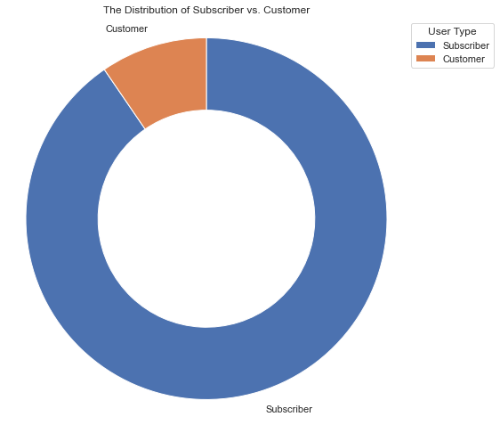

```python
# Plot the distribution of user type
# Use matplotlib.pyplot.pie() function to plot a pie chart (Donut chart)
sorted_counts = df['user_type'].value_counts()
# Use matplotlib.figure() function to control the default spacing of the subplots and the top level container of the subplots,
# and the top level container for all plot elements.
plt.figure(figsize=[ 11.69, 8.27])
# Use matplotlib.pyplot.title() to set a title for the axes.
plt.title('The Distribution of Subscriber vs. Customer');
# Use matplotlib.pyplot.pie() function to plot a pie chart, with this parameters to create the donut plot.
plt.pie(sorted_counts, labels = sorted_counts.index, startangle = 90, counterclock = False, wedgeprops = {'width' : 0.4});
# Use matplotlib.pyplot.axis('square') to create a square plot with equal axes
plt.axis('square');
# Use matplotlib.pyplot.legend() function to place a legend on the axes
plt.legend(title ="User Type",loc ="upper left",bbox_to_anchor =(1, 0, 0.5, 1));
# Use matplotlib.pyplot.show() function to display all figures.
plt.show();
```

**Observation**

#### Plotting 'member_gender' feature

```python
df['member_gender'].value_counts()
```

```
Male      126311
Female     40098
Other       3583
Name: member_gender, dtype: int64
```

```python
df.member_gender.value_counts(normalize=True)
```

```
Male      0.743041
Female    0.235882
Other     0.021077
Name: member_gender, dtype: float64
```

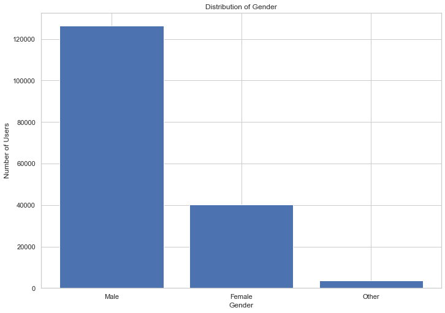

```python
# plotting the distribution of Bikers' gender

# Use matplotlib.figure() function to control the default spacing of the subplots and the top level container of the subplots,
# and the top level container for all plot elements.
plt.figure(figsize=[ 11.69, 8.27])
# Use matplotlib.pyplot.bar() function to make a bar plot.
plt.bar(x = df.member_gender.value_counts().keys(), height = df.member_gender.value_counts() )
# Use matplotlib.pyplot.title() to set a title for the axes.
plt.title('Distribution of Gender')
# Use matplotlib.pyplot.xlabel to set the label for the x-axis
plt.xlabel('Gender')
# Use matplotlib.pyplot.ylabel to set the label for the y-axis.
plt.ylabel('Number of Users')
# Use matplotlib.pyplot.show () function to display all open figures.
plt.show();
```

**Observation**

- The male bikers are about three times of female bikers.
- The value counts of "Male", "Female", and "Other" are 126311, 40098, and 3583 respectively.
- However, the percentage of "Male" is approximately 74%, "Female" is approximately 24%, and "Other" is approximately 2% off the "Gender" feature.
- In other words,the number of times a data value occurs or the frequency of "Male" is greater than the frequency of "Female" and "Other" in the "Gender" feature.

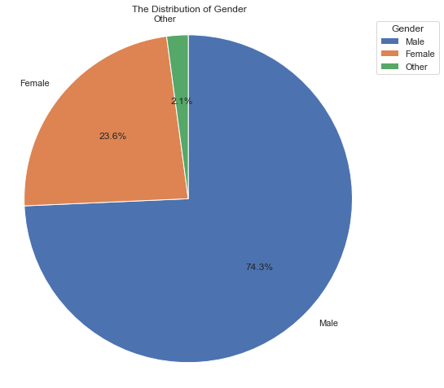

```python
# Ploting the distribution of bikers' gender

# Use matplotlib.pyplot.pie() function to plot a pie chart
sorted_counts = df['member_gender'].value_counts()
# Use matplotlib.figure() function to control the default spacing of the subplots and the top level container of the subplots,
# and the top level container for all plot elements.
plt.figure(figsize=[ 11.69, 8.27]);
# Use matplotlib.pyplot.title() to set a title for the axes.
plt.title('The Distribution of Gender');
# Use matplotlib.pyplot.pie() function to plot a pie chart
plt.pie(sorted_counts, labels = sorted_counts.index, startangle = 90, counterclock = False, autopct='%1.1f%%');
# Use matplotlib.pyplot.axis('square') to create a square plot with equal axes
plt.axis('square');
# Use matplotlib.pyplot.legend() function to place a legend on the axes
plt.legend(title ="Gender",loc ="upper left",bbox_to_anchor =(1, 0, 0.5, 1));
# Use matplotlib.pyplot.show() function to display all figures.
plt.show();
```

**Observation**

- The male bikers are about three times of female bikers.
- The value counts of "Male", "Female", and "Other" are 126311, 40098, and 3583 respectively.
- However, the percentage of "Male" is approximately 74%, "Female" is approximately 24%, and "Other" is approximately 2% off the "Gender" feature.
- In other words,the number of times a data value occurs or the frequency of "Male" is greater than the frequency of "Female" and "Other" in the "Gender" feature.